# Astrazeneca completed test

[figure not shown]

```
                                                                  Hurgland-Nick KELIET
```

[My Github](https://github.com/Hurgland-Nick) : Github Link

```
                                         ASTRAZENECA TEST
```

#### import modules

```python
# conventional way to import pandas and requests
import pandas as pd
import requests

# Visualisation
import matplotlib.pyplot as plt
%matplotlib inline
import seaborn as sns
sns.set()

# check the current setting for the 'max_rows' and 'max_columns' option
pd.set_option('display.max_rows', None)
pd.set_option('display.max_columns', None)

# Machine Learning
# Sklearn
from sklearn.model_selection import train_test_split
from sklearn.linear_model import LinearRegression, SGDRegressor
from sklearn import metrics


# SQL import for query quickly
#import pandasql as pdsql
from pandasql import sqldf
pysqldf = lambda q: sqldf(q, globals())

# Import Pandas_profiling
import pandas_profiling

# Avoid warnings
import warnings
warnings.filterwarnings('ignore')
```

[output not shown]

[output cut: 29 more lines]

[output not shown]

#### Queries data on the API "Open FDA"

```python
URL = 'https://api.fda.gov/drug/label.json?search=openfda.manufacturer_name.exact:%22AstraZeneca+Pharmaceuticals+LP%22&limit=100'
data = requests.get(URL).json()
```

# Pre-Processing

```python
# Let's convert our previous outcome to dataframe
query_openfda = pd.DataFrame.from_dict(data['results'])

# Quick check of the data
query_openfda.head(2)
```

|  | effective_time | drug_interactions | recent_major_changes | geriatric_use | instructions_for_use | pharmacodynamics | description | nonclinical_toxicology | dosage_forms_and_strengths | mechanism_of_action | pharmacokinetics | clinical_studies_table | indications_and_usage | set_id | id | pediatric_use | contraindications | drug_interactions_table | spl_product_data_elements | boxed_warning | adverse_reactions_table | warnings_and_cautions | openfda | version | dosage_and_administration | adverse_reactions | use_in_specific_populations | how_supplied | information_for_patients | … |
| --- | --- | --- | --- | --- | --- | --- | --- | --- | --- | --- | --- | --- | --- | --- | --- | --- | --- | --- | --- | --- | --- | --- | --- | --- | --- | --- | --- | --- | --- | --- |
| 0 | 20190725 | [7 DRUG INTERACTIONS Table 3: Clinically Relev... | [Indications and Usage, Limitations of Use (1)... | [8.5 Geriatric Use In two comparator-controlle... | [INSTRUCTIONS FOR USE Once-weekly BYDUREON BCI... | [12.2 Pharmacodynamics Exenatide improves glyc... | [11 DESCRIPTION BYDUREON BCISE (exenatide exte... | [13 NONCLINICAL TOXICOLOGY 13.1 Carcinogenesis... | [3 DOSAGE FORMS AND STRENGTHS Extended-release... | [12.1 Mechanism of Action Incretins, such as g... | [12.3 Pharmacokinetics Absorption Following a ... | [<table width="100%"> <caption>Table 4: Result... | [1 INDICATIONS AND USAGE BYDUREON BCISE is ind... | 2d18cfc4-e0de-4814-a712-c1b7c504bff5 | 6c84817c-b737-4d93-bedf-9777c0c310a8 | [8.4 Pediatric Use Safety and effectiveness of... | [4 CONTRAINDICATIONS BYDUREON BCISE is contrai... | [<table width="100%"> <col width="16%"/> <col ... | [BYDUREON BCise exenatide EXENATIDE EXENATIDE ... | [WARNING: RISK OF THYROID C-CELL TUMORS • Exen... | [<table width="99.02%"> <caption>Table 1: Adve... | [5 WARNINGS AND PRECAUTIONS • Acute Pancreatit... | {'product_ndc': ['0310-6540'], 'is_original_pa... | 15 | [2 DOSAGE AND ADMINISTRATION •Administer 2 mg ... | [6 ADVERSE REACTIONS The following serious adv... | [8 USE IN SPECIFIC POPULATIONS • Pregnancy: Us... | [16 HOW SUPPLIED/STORAGE AND HANDLING How Supp... | [17 PATIENT COUNSELING INFORMATION Advise the ... | … |
| 1 | 20190613 | [7 DRUG INTERACTIONS Table 4: Clinically Relev... | [Indications and Usage (1) 05/2019 Dosage and ... | [8.5 Geriatric Use Because elderly patients ar... | NaN | [12.2 Pharmacodynamics Dapagliflozin Increases... | [11 DESCRIPTION QTERN tablets for oral use con... | [13 NONCLINICAL TOXICOLOGY 13.1 Carcinogenesis... | [3 DOSAGE FORMS AND STRENGTHS Tablets: •5 mg d... | [12.1 Mechanism of Action QTERN contains: dapa... | [12.3 Pharmacokinetics Overall, the pharmacoki... | [<table width="99.84%"> <caption>Table 9: HbA1... | [1 INDICATIONS AND USAGE QTERN (dapagliflozin ... | 423c489c-085b-4320-b892-7868ebd6dc6b | 95feb35d-4b78-4a9d-9ad4-b3fd60b796fc | [8.4 Pediatric Use Safety and effectiveness of... | [4 CONTRAINDICATIONS QTERN is contraindicated ... | [<table width="100%"> <caption>Table 4: Clinic... | [QTERN dapagliflozin and saxagliptin DAPAGLIFL... | NaN | [<table width="100%"> <caption>Table 1: Advers... | [5 WARNINGS AND PRECAUTIONS Pancreatitis: If p... | {'product_ndc': ['0310-6770', '0310-6780'], 'i... | 14 | [2 DOSAGE AND ADMINISTRATION •Assess renal fun... | [6 ADVERSE REACTIONS The following important a... | [8 USE IN SPECIFIC POPULATIONS Pregnancy: Advi... | [16 HOW SUPPLIED/STORAGE AND HANDLING How Supp... | [17 PATIENT COUNSELING INFORMATION Advise the ... | … |

#### Size of our general dataframe

```python
# Size of our general dataframe
print('Our combined_data has {} rows and {} columns'.format(query_openfda.shape[0],query_openfda.shape[1]))
```

```
Our combined_data has 27 rows and 59 columns
```

NB: We can see that our main dataframe hides an 'openfda' column which contains some data such as the 'manufacturer_name' and 'spl_product necessary for our final request

#### Extract the 'openfda' column to process it

```python
# Check the structure of our hidden dataset
query_openfda['openfda'].head()
```

```
0    {'product_ndc': ['0310-6540'], 'is_original_pa...
1    {'product_ndc': ['0310-6770', '0310-6780'], 'i...
2    {'product_ndc': ['0186-0324', '0186-0322', '01...
3    {'product_ndc': ['0186-1090', '0186-1088', '01...
4    {'product_ndc': ['0310-6627', '0310-6615'], 'i...
Name: openfda, dtype: object
```

```python
# Check the type
type(query_openfda['openfda'])
```

```
pandas.core.series.Series
```

We saw that our openfda column has a structure like a Dictionary but it's not, let's treate it

```python
# Convert 'openfda' column to Dictionaire cause he wad
dic = query_openfda['openfda'].to_dict()
dic
```

```
{0: {'product_ndc': ['0310-6540'],
  'is_original_packager': [True],
  'package_ndc': ['0310-6540-85', '0310-6540-04', '0310-6540-01'],
  'generic_name': ['EXENATIDE'],
  'spl_set_id': ['2d18cfc4-e0de-4814-a712-c1b7c504bff5'],
  'brand_name': ['BYDUREON BCise'],
  'manufacturer_name': ['AstraZeneca Pharmaceuticals LP'],
  'unii': ['9P1872D4OL'],
  'rxcui': ['1990866', '1990869'],
  'spl_id': ['6c84817c-b737-4d93-bedf-9777c0c310a8'],
  'substance_name': ['EXENATIDE'],
  'product_type': ['HUMAN PRESCRIPTION DRUG'],
  'route': ['SUBCUTANEOUS'],
  'application_number': ['NDA209210']},
 1: {'product_ndc': ['0310-6770', '0310-6780'],
  'is_original_packager': [True],
  'package_ndc': ['0310-6770-95',
   '0310-6770-30',
   '0310-6780-30',
   '0310-6780-95'],
  'generic_name': ['DAPAGLIFLOZIN AND SAXAGLIPTIN'],
  'spl_set_id': ['423c489c-085b-4320-b892-7868ebd6dc6b'],
  'upc': ['0303106770304'],
  'brand_name': ['QTERN'],
  'manufacturer_name': ['AstraZeneca Pharmaceuticals LP'],
  'unii': ['Z8J84YIX6L', '1ULL0QJ8UC'],
  'rxcui': ['2169274', '2169276', '1925498', '1925504'],
  'spl_id': ['95feb35d-4b78-4a9d-9ad4-b3fd60b796fc'],
  'substance_name': ['SAXAGLIPTIN HYDROCHLORIDE', 'DAPAGLIFLOZIN'],
  'product_type': ['HUMAN PRESCRIPTION DRUG'],
  'route': ['ORAL'],
  'application_number': ['NDA209091']},
 2: {'product_ndc': ['0186-0324', '0186-0322', '0186-0162'],
  'is_original_packager': [True],
  'package_ndc': ['0186-0162-28',
   '0186-0162-54',
   '0186-0322-54',
   '0186-0322-28',
   '0186-0324-54'],
  'generic_name': ['CANDESARTAN CILEXETIL AND HYDROCHLOROTHIAZIDE'],
```

[output cut: 473 more lines]

```
  'package_ndc': ['0186-0384-30',
   '0186-0384-90',
   '0186-0382-90',
   '0186-0382-30'],
  'generic_name': ['ESOMEPRAZOLE MAGNESIUM'],
  'spl_set_id': ['fd73c5c8-3a76-449b-8d7f-54fdda2391c4'],
  'brand_name': ['Esomeprazole magnesium'],
  'manufacturer_name': ['AstraZeneca Pharmaceuticals LP'],
  'unii': ['R6DXU4WAY9'],
  'rxcui': ['606730', '606726'],
  'spl_id': ['b2b5d745-1be2-4504-a56e-d525e069634b'],
  'substance_name': ['ESOMEPRAZOLE MAGNESIUM'],
  'product_type': ['HUMAN PRESCRIPTION DRUG'],
  'route': ['ORAL'],
  'application_number': ['NDA021153']}}
```

We have to transpose it cause further we want to use this dataframe later with the right number of row

```python
# Let's Transpose the openfda column
df_openfda = pd.DataFrame.from_dict(dic).T

# Let's take a look at the openfda DataFrame:
df_openfda.head()
```

|  | product_ndc | is_original_packager | package_ndc | generic_name | spl_set_id | brand_name | manufacturer_name | unii | rxcui | spl_id | substance_name | product_type | route | application_number | upc |
| --- | --- | --- | --- | --- | --- | --- | --- | --- | --- | --- | --- | --- | --- | --- | --- |
| 0 | [0310-6540] | [True] | [0310-6540-85, 0310-6540-04, 0310-6540-01] | [EXENATIDE] | [2d18cfc4-e0de-4814-a712-c1b7c504bff5] | [BYDUREON BCise] | [AstraZeneca Pharmaceuticals LP] | [9P1872D4OL] | [1990866, 1990869] | [6c84817c-b737-4d93-bedf-9777c0c310a8] | [EXENATIDE] | [HUMAN PRESCRIPTION DRUG] | [SUBCUTANEOUS] | [NDA209210] | NaN |
| 1 | [0310-6770, 0310-6780] | [True] | [0310-6770-95, 0310-6770-30, 0310-6780-30, 031... | [DAPAGLIFLOZIN AND SAXAGLIPTIN] | [423c489c-085b-4320-b892-7868ebd6dc6b] | [QTERN] | [AstraZeneca Pharmaceuticals LP] | [Z8J84YIX6L, 1ULL0QJ8UC] | [2169274, 2169276, 1925498, 1925504] | [95feb35d-4b78-4a9d-9ad4-b3fd60b796fc] | [SAXAGLIPTIN HYDROCHLORIDE, DAPAGLIFLOZIN] | [HUMAN PRESCRIPTION DRUG] | [ORAL] | [NDA209091] | [0303106770304] |
| 2 | [0186-0324, 0186-0322, 0186-0162] | [True] | [0186-0162-28, 0186-0162-54, 0186-0322-54, 018... | [CANDESARTAN CILEXETIL AND HYDROCHLOROTHIAZIDE] | [48b021e4-5897-42fd-12be-3190a9b087e8] | [ATACAND HCT] | [AstraZeneca Pharmaceuticals LP] | [R85M2X0D68, 0J48LPH2TH] | [802749, 805863, 578330, 578325, 805859, 805855] | [9e314974-b835-461b-b4f4-9f3660ea83ae] | [HYDROCHLOROTHIAZIDE, CANDESARTAN CILEXETIL] | [HUMAN PRESCRIPTION DRUG] | [ORAL] | [NDA021093] | NaN |
| 3 | [0186-1090, 0186-1088, 0186-1092, 0186-1094] | [True] | [0186-1088-30, 0186-1092-05, 0186-1088-35, 018... | [METOPROLOL SUCCINATE] | [4a5762c6-d7a2-4e4c-10b7-8832b36fa5f4] | [TOPROL XL] | [AstraZeneca Pharmaceuticals LP] | [TH25PD4CCB] | [866414, 866412, 866421, 866436, 866438, 86642... | [03b2ba2e-c4b7-449d-8e07-9c0e08171f66] | [METOPROLOL SUCCINATE] | [HUMAN PRESCRIPTION DRUG] | [ORAL] | [NDA019962] | NaN |
| 4 | [0310-6627, 0310-6615] | [True] | [0310-6627-02, 0310-6615-02] | [PRAMLINTIDE ACETATE] | [4aea30ff-eb0d-45c1-b114-3127966328ff] | [SymlinPen] | [AstraZeneca Pharmaceuticals LP] | [726I6TE06G] | [861043, 861042, 861045, 861044] | [15ee192e-97e1-4867-9b0d-b093b841e939] | [PRAMLINTIDE ACETATE] | [HUMAN PRESCRIPTION DRUG] | [SUBCUTANEOUS] | [NDA021332] | NaN |

NB: Now that we have the release of the open column FDA, combine it with the 'effective_time' and 'spl_product_data_elements' columns from the general dataframe

### Let's select the columns we want to build our new dataframe

```python
# Creating new dataframe from the general dataframe
cols_query_openfda = ['effective_time','spl_product_data_elements']
query_openfda_1 = query_openfda.loc[:,cols_query_openfda]

# Creating a new dataframe from the openfda columns inside the general dataframe 'query_openfda'
cols_openfda = ['manufacturer_name','brand_name','route']
query_openfda_2 =  df_openfda.loc[:,cols_openfda]
```

- Let's create a single dataset with the useful values

# Part A

#### Now we have the data we want to work with for the first question (i included 'Route' columns for the part B)

```python
# frames with the two dataset concatened by columns
df_raw_data = pd.concat([query_openfda_1, query_openfda_2], axis=1)

# Quick check all of the 27 columns
df_raw_data.head(28)
```

|  | effective_time | spl_product_data_elements | manufacturer_name | brand_name | route |
| --- | --- | --- | --- | --- | --- |
| 0 | 20190725 | [BYDUREON BCise exenatide EXENATIDE EXENATIDE ... | [AstraZeneca Pharmaceuticals LP] | [BYDUREON BCise] | [SUBCUTANEOUS] |
| 1 | 20190613 | [QTERN dapagliflozin and saxagliptin DAPAGLIFL... | [AstraZeneca Pharmaceuticals LP] | [QTERN] | [ORAL] |
| 2 | 20160705 | [ATACAND HCT Candesartan cilexetil and Hydroch... | [AstraZeneca Pharmaceuticals LP] | [ATACAND HCT] | [ORAL] |
| 3 | 20160607 | [TOPROLXL Metoprolol succinate METOPROLOL SUCC... | [AstraZeneca Pharmaceuticals LP] | [TOPROL XL] | [ORAL] |
| 4 | 20160415 | [SymlinPen pramlintide acetate pramlintide ace... | [AstraZeneca Pharmaceuticals LP] | [SymlinPen] | [SUBCUTANEOUS] |
| 5 | 20160331 | [CAPRELSA Vandetanib VANDETANIB VANDETANIB CAL... | [AstraZeneca Pharmaceuticals LP] | [CAPRELSA] | [ORAL] |
| 6 | 20161101 | [ZOLADEX Goserelin acetate GOSERELIN ACETATE G... | [AstraZeneca Pharmaceuticals LP] | [ZOLADEX] | [SUBCUTANEOUS] |
| 7 | 20181221 | [Byetta exenatide exenatide exenatide metacres... | [AstraZeneca Pharmaceuticals LP] | [Byetta] | [SUBCUTANEOUS] |
| 8 | 20180927 | [Lynparza olaparib OLAPARIB OLAPARIB HYPROMELL... | [AstraZeneca Pharmaceuticals LP] | [Lynparza] | [ORAL] |
| 9 | 20180828 | [TAGRISSO osimertinib OSIMERTINIB OSIMERTINIB ... | [AstraZeneca Pharmaceuticals LP] | [TAGRISSO] | [ORAL] |
| 10 | 20161101 | [ZOLADEX Goserelin acetate GOSERELIN ACETATE G... | [AstraZeneca Pharmaceuticals LP] | [ZOLADEX] | [SUBCUTANEOUS] |
| 11 | 20190215 | [BYDUREON exenatide EXENATIDE EXENATIDE POLY(D... | [AstraZeneca Pharmaceuticals LP] | [BYDUREON] | NaN |
| 12 | 20190514 | [IRESSA Gefitinib GEFITINIB GEFITINIB LACTOSE ... | [AstraZeneca Pharmaceuticals LP] | [IRESSA] | [ORAL] |
| 13 | 20190826 | [IMFINZI Durvalumab DURVALUMAB DURVALUMAB HIST... | [AstraZeneca Pharmaceuticals LP] | [IMFINZI] | [INTRAVENOUS] |
| 14 | 20180731 | [LOKELMA sodium zirconium cyclosilicate SODIUM... | [AstraZeneca Pharmaceuticals LP] | [LOKELMA] | [ORAL] |
| 15 | 20161222 | [PRILOSEC Omeprazole magnesium OMEPRAZOLE MAGN... | [AstraZeneca Pharmaceuticals LP] | [PRILOSEC] | [ORAL] |
| 16 | 20160705 | [ATACAND Candesartan cilexetil CANDESARTAN CIL... | [AstraZeneca Pharmaceuticals LP] | [ATACAND] | [ORAL] |
| 17 | 20190410 | [Tudorza Pressair aclidinium bromide ACLIDINIU... | [AstraZeneca Pharmaceuticals LP] | [Tudorza Pressair] | [RESPIRATORY (INHALATION)] |
| 18 | 20190529 | [BEVESPI AEROSPHERE Glycopyrrolate and formote... | [AstraZeneca Pharmaceuticals LP] | [BEVESPI AEROSPHERE] | [RESPIRATORY (INHALATION)] |
| 19 | 20181109 | [CRESTOR Rosuvastatin calcium ROSUVASTATIN CAL... | [AstraZeneca Pharmaceuticals LP] | [CRESTOR] | [ORAL] |
| 20 | 20190930 | [NEXIUMI.V. Esomeprazole sodium ESOMEPRAZOLE S... | [AstraZeneca Pharmaceuticals LP] | [NEXIUM I.V.] | [INTRAVENOUS] |
| 21 | 20180123 | [Daliresp roflumilast roflumilast roflumilast ... | [AstraZeneca Pharmaceuticals LP] | [Daliresp] | [ORAL] |
| 22 | 20190125 | [LUMOXITI moxetumomab pasudotox MOXETUMOMAB PA... | [AstraZeneca Pharmaceuticals LP] | [LUMOXITI] | [INTRAVENOUS] |
| 23 | 20180607 | [NEXIUM Esomeprazole magnesium ESOMEPRAZOLE MA... | [AstraZeneca Pharmaceuticals LP] | [NEXIUM] | [ORAL] |
| 24 | 20190529 | [MOVANTIK naloxegol oxalate NALOXEGOL OXALATE ... | [AstraZeneca Pharmaceuticals LP] | [MOVANTIK] | [ORAL] |
| 25 | 20190724 | [SYMBICORT Budesonide and Formoterol Fumarate ... | [AstraZeneca Pharmaceuticals LP] | [SYMBICORT] | [RESPIRATORY (INHALATION)] |
| 26 | 20180607 | [Esomeprazole magnesium Esomeprazole magnesium... | [AstraZeneca Pharmaceuticals LP] | [Esomeprazole magnesium] | [ORAL] |

```python
# Type df_partA
type(df_raw_data)
```

```
pandas.core.frame.DataFrame
```

```python
# Size of our final dataframe
print('Our combined_data has {} rows and {} columns'.format(df_raw_data.shape[0],df_raw_data.shape[1]))
```

```
Our combined_data has 27 rows and 5 columns
```

```python
# Check the type of our columns
df_raw_data.dtypes
```

```
effective_time               object
spl_product_data_elements    object
manufacturer_name            object
brand_name                   object
route                        object
dtype: object
```

### Convert Columns

- Effective_time

```python
# Let's convert 'effective_time' to date.
# Unfortunately the column is not in datetime structure, let's do it manually and convert it to year
df_raw_data['effective_time'] = df_raw_data['effective_time'].str[0:4]
```

```python
# rename 'effective_time' to 'year'
df_partA = df_raw_data.rename({'effective_time':'year'}, axis = 'columns')

# Put 'year' in datetime format
df_partA['year'] = df_partA['year'].astype(int)
df_partA.dtypes
```

```
year                          int32
spl_product_data_elements    object
manufacturer_name            object
brand_name                   object
route                        object
dtype: object
```

- Brand_name

```python
# Convert to string
df_partA['brand_name'] = df_partA['brand_name'].apply(lambda x: str(x))

# rename 'brand_name' to 'drug_names'
df_partA = df_partA.rename({'brand_name':'drug_names'}, axis = 'columns')
```

- manufacturer_name & brand_name

```python
# Let's convert 'spl_product_data_elements', 'manufacturer_name' , 'brand_name' to string.
# 'spl_product_data_elements'
df_partA['spl_product_data_elements'] = df_partA['spl_product_data_elements'].apply(lambda x: str(x))

# 'manufacturer_name'
df_partA['manufacturer_name'] = df_partA['manufacturer_name'].apply(lambda x: str(x))
df_partA.head()
```

|  | year | spl_product_data_elements | manufacturer_name | drug_names | route |
| --- | --- | --- | --- | --- | --- |
| 0 | 2019 | ['BYDUREON BCise exenatide EXENATIDE EXENATIDE... | ['AstraZeneca Pharmaceuticals LP'] | ['BYDUREON BCise'] | [SUBCUTANEOUS] |
| 1 | 2019 | ['QTERN dapagliflozin and saxagliptin DAPAGLIF... | ['AstraZeneca Pharmaceuticals LP'] | ['QTERN'] | [ORAL] |
| 2 | 2016 | ['ATACAND HCT Candesartan cilexetil and Hydroc... | ['AstraZeneca Pharmaceuticals LP'] | ['ATACAND HCT'] | [ORAL] |
| 3 | 2016 | ['TOPROLXL Metoprolol succinate METOPROLOL SUC... | ['AstraZeneca Pharmaceuticals LP'] | ['TOPROL XL'] | [ORAL] |
| 4 | 2016 | ['SymlinPen pramlintide acetate pramlintide ac... | ['AstraZeneca Pharmaceuticals LP'] | ['SymlinPen'] | [SUBCUTANEOUS] |

- route

```python
# Convert route columns to string
df_partA['route'] = df_partA['route'].apply(lambda x: str(x))
```

```python
# double replace string methods
# 'spl_product_data_elements'
df_partA['spl_product_data_elements'] = df_partA['spl_product_data_elements'].str.replace("[","").str.replace("]","").astype(str)

# 'manufacturer_name'
df_partA['manufacturer_name'] = df_partA['manufacturer_name'].str.replace("[","").str.replace("]","").astype(str)
df_partA['manufacturer_name'] = df_partA['manufacturer_name'].str.replace("'","").astype(str)

# Brand_name
df_partA['drug_names'] = df_partA['drug_names'].str.replace("[", "").str.replace("]", "").astype(str)
df_partA['drug_names'] = df_partA['drug_names'].str.replace("'","").astype(str).astype(str)

# route
df_partA['route'] = df_partA['route'].str.replace("[", "").str.replace("]", "").astype(str)
df_partA['route'] = df_partA['route'].str.replace("'","").astype(str).astype(str)

# Quick view
df_partA.head()
```

|  | year | spl_product_data_elements | manufacturer_name | drug_names | route |
| --- | --- | --- | --- | --- | --- |
| 0 | 2019 | 'BYDUREON BCise exenatide EXENATIDE EXENATIDE ... | AstraZeneca Pharmaceuticals LP | BYDUREON BCise | SUBCUTANEOUS |
| 1 | 2019 | 'QTERN dapagliflozin and saxagliptin DAPAGLIFL... | AstraZeneca Pharmaceuticals LP | QTERN | ORAL |
| 2 | 2016 | 'ATACAND HCT Candesartan cilexetil and Hydroch... | AstraZeneca Pharmaceuticals LP | ATACAND HCT | ORAL |
| 3 | 2016 | 'TOPROLXL Metoprolol succinate METOPROLOL SUCC... | AstraZeneca Pharmaceuticals LP | TOPROL XL | ORAL |
| 4 | 2016 | 'SymlinPen pramlintide acetate pramlintide ace... | AstraZeneca Pharmaceuticals LP | SymlinPen | SUBCUTANEOUS |

#### NB: I face a problem about how to count the number of ingredient if he has to be found in the column spl_product_data_elements, I will suppose for now that the number is determined by the number of commas that i encountered on each row, i don't reaaly know. i could have clean it if i had more knowledge on drugs and its ingredients.

```python
# acording to the description of the field that said :
# spl_product_data_elements == 'Usually a list of ingredients in a drug product'.
df_partA['number_of_ingredient'] = df_partA['spl_product_data_elements'].apply(lambda x: int(len(x.split(',')) + 1))
```

```python
data = df_partA.copy()
data.head()
```

|  | year | spl_product_data_elements | manufacturer_name | drug_names | route | number_of_ingredient |
| --- | --- | --- | --- | --- | --- | --- |
| 0 | 2019 | 'BYDUREON BCise exenatide EXENATIDE EXENATIDE ... | AstraZeneca Pharmaceuticals LP | BYDUREON BCise | SUBCUTANEOUS | 8 |
| 1 | 2019 | 'QTERN dapagliflozin and saxagliptin DAPAGLIFL... | AstraZeneca Pharmaceuticals LP | QTERN | ORAL | 4 |
| 2 | 2016 | 'ATACAND HCT Candesartan cilexetil and Hydroch... | AstraZeneca Pharmaceuticals LP | ATACAND HCT | ORAL | 5 |
| 3 | 2016 | 'TOPROLXL Metoprolol succinate METOPROLOL SUCC... | AstraZeneca Pharmaceuticals LP | TOPROL XL | ORAL | 2 |
| 4 | 2016 | 'SymlinPen pramlintide acetate pramlintide ace... | AstraZeneca Pharmaceuticals LP | SymlinPen | SUBCUTANEOUS | 2 |

```python
data['liste_ingredient'] = [list() for x in range(len(data.index))]
data['contains'] = [bool() for x in range(len(data.index))]
```

```python
data['spl_product_data_elements'][0]
data.head()
```

|  | year | spl_product_data_elements | manufacturer_name | drug_names | route | number_of_ingredient | liste_ingredient | contains |
| --- | --- | --- | --- | --- | --- | --- | --- | --- |
| 0 | 2019 | 'BYDUREON BCise exenatide EXENATIDE EXENATIDE ... | AstraZeneca Pharmaceuticals LP | BYDUREON BCise | SUBCUTANEOUS | 8 | [] | False |
| 1 | 2019 | 'QTERN dapagliflozin and saxagliptin DAPAGLIFL... | AstraZeneca Pharmaceuticals LP | QTERN | ORAL | 4 | [] | False |
| 2 | 2016 | 'ATACAND HCT Candesartan cilexetil and Hydroch... | AstraZeneca Pharmaceuticals LP | ATACAND HCT | ORAL | 5 | [] | False |
| 3 | 2016 | 'TOPROLXL Metoprolol succinate METOPROLOL SUCC... | AstraZeneca Pharmaceuticals LP | TOPROL XL | ORAL | 2 | [] | False |
| 4 | 2016 | 'SymlinPen pramlintide acetate pramlintide ace... | AstraZeneca Pharmaceuticals LP | SymlinPen | SUBCUTANEOUS | 2 | [] | False |

### Thanks to the site: [dailymed.nlm.nih.gov](https://dailymed.nlm.nih.gov/dailymed/drugInfo.cfm?setid=a1b077e6-b070-43f2-a98e-380cc635419d)

I was able to compare the ingredients of each drug_names with that of the composition of the real drug. But it can be very laborious when we are dealing with a multitutide of drugs. According to the official pdf of Open fda explaining that this field contains a list of drugs, we tell ourselves from the start that we will just have to count the size of the list, which is not the right approach. Is it done on purpose?

```python
#https://dailymed.nlm.nih.gov/dailymed/drugInfo.cfm?setid=a1b077e6-b070-43f2-a98e-380cc635419d
search_list = ["lactose","corn starch","exenatide","POLYDL-LACTIC-CO-GLYCOLIC ACID","SODIUM CHLORIDE",
               "POLYSORBATE 20 SODIUM PHOSPHATE","MONOBASIC","MONOHYDRATE SODIUM PHOSPHATE","DIBASIC",
               "HEPTAHYDRATE WATER","SUCROSE CARBOXYMETHYLCELLULOSE SODIUM","metacresol", "mannitol",
               "acetic acid", "sodium acetate", "water","Goserelin acetate","GOSERELIN GLYCOLIC ACID LACTIC ACID",
               "pramlintide acetate","olaparib","HYPROMELLOSE","TITANIUM DIOXIDE","GELLAN GUM(LOW ACYL)",
               "POTASSIUM ACETATE","SHELLAC","ISOPROPYL ALCOHOL","BUTYL ALCOHOL","PROPYLENE GLYCOL","AMMONIA",
               "LAUROYL PEG-32 GLYCERIDES","Vandetanib","CALCIUM PHOSPHATE","DIHYDRATE CELLULOSE","MICROCRYSTALLINE",
               "CROSPOVIDONE (15 MPA.S AT 5%)","MAGNESIUM STEARATE","HYPROMELLOSES","POLYETHYLENE GLYCOL","CELLULOSE",
               "TALC","SODIUM STEARYL FUMARATE","OSIMERTINIB","POLYVINYL ALCOHOL","FERRIC OXIDE YELLOW",
               "FERRIC OXIDE RED","FERROSOFERRIC OXIDE","LOW-SUBSTITUTED HYDROXYPROPYL","Candesartan cilexetil",
               "Hydrochlorothiazide","STARCH, CORN","LACTOSE MONOHYDRATE","CALCIUM HYDROXYPROPYL","Durvalumab",
               "HISTIDINE","HISTIDINE MONOHYDROCHLORIDE MONOHYDRATE","TREHALOSE DIHYDRATE","POLYSORBATE","dapagliflozin",
               "SAXAGLIPTIN HYDROCHLORIDE","ANHYDROUS LACTOSE","SILICON DIOXIDE","FERROUS OXIDE","CROSCARMELLOSE SODIUM",
               "MICROCRYSTALLINE CELLULOSE","Gefitinib","POVIDONE","SODIUM LAURYL SULFATE","PARAFFIN","TARTRATE",
               "METOPROLOL SUCCINATE","SODIUM ZIRCONIUM CYCLOSILICATE","Esomeprazole magnesium","GLYCERYL MONOSTEARATE",
               "HYDROXYPROPYL CELLULOSE","METHACRYLIC ACID","TRIETHYL CITRATE","GELATIN","FD&C BLUE NO. 1",
               "FD&C RED NO. 40","ALCOHOL","SODIUM HYDROXIDE","Budesonide","FORMOTEROL FUMARATE","POVIDONE K25",
               "APAFLURANE","naloxegol oxalate","CELLULOSE, MICROCRYSTALLINE","PROPYL GALLATE","D&C RED NO. 28",
               "D&C YELLOW NO. 10","POTASSIUM SORBATE","ANHYDROUS DEXTROSE","Amethyst NEXIUM","ANHYDROUS CITRIC",
               "GLYCINE","SODIUM PHOSPHATE, MONOBASIC, MONOHYDRATE","SUCROSE","moxetumomab pasudotox",
               "CITRIC ACID MONOHYDRATE","TRISODIUM","citrate","roflumilast","Esomeprazole sodium","EDETATE DISODIUM",
               "Rosuvastatin calcium","TRIBASIC CALCIUM PHOSPHATE","TRIACETIN","Glycopyrrolate",
               "1,2-DISTEAROYL-SN-GLYCERO-3-PHOSPHOCHOLINE","CALCIUM CHLORIDE","NORFLURANE","GLYCOPYRROLATE",
               "aclidinium bromide","Omeprazole magnesium","HYDROXYPROPYL CELLULOSE (TYPE H)","FD&C BLUE NO. 2",
               "D&C RED NO. 7","LACTIC ACID, DL-","GLYCOLIC ACID"
              ]
data['number_of_ingredient'] = 0
for i in range(0,len(data)):
    for word in search_list:
        data['contains'] = data['spl_product_data_elements'].str.contains(word, case = True)
       # data['nb_ing'] = data['nb_ing'][i]
        if(data['contains'][i] == True):
            data['number_of_ingredient'][i] = data['number_of_ingredient'][i] + 1
            data['liste_ingredient'][i].append(word)
        else:
            data['number_of_ingredient'][i] = data['number_of_ingredient'][i] + 0
data = data.head(30)
data
```

|  | year | spl_product_data_elements | manufacturer_name | drug_names | route | number_of_ingredient | liste_ingredient | contains |
| --- | --- | --- | --- | --- | --- | --- | --- | --- |
| 0 | 2019 | 'BYDUREON BCise exenatide EXENATIDE EXENATIDE ... | AstraZeneca Pharmaceuticals LP | BYDUREON BCise | SUBCUTANEOUS | 13 | [exenatide, SODIUM CHLORIDE, POLYSORBATE 20 SO... | True |
| 1 | 2019 | 'QTERN dapagliflozin and saxagliptin DAPAGLIFL... | AstraZeneca Pharmaceuticals LP | QTERN | ORAL | 15 | [TITANIUM DIOXIDE, MICROCRYSTALLINE, MAGNESIUM... | False |
| 2 | 2016 | 'ATACAND HCT Candesartan cilexetil and Hydroch... | AstraZeneca Pharmaceuticals LP | ATACAND HCT | ORAL | 11 | [MAGNESIUM STEARATE, POLYETHYLENE GLYCOL, CELL... | False |
| 3 | 2016 | 'TOPROLXL Metoprolol succinate METOPROLOL SUCC... | AstraZeneca Pharmaceuticals LP | TOPROL XL | ORAL | 9 | [HYPROMELLOSE, TITANIUM DIOXIDE, HYPROMELLOSES... | False |
| 4 | 2016 | 'SymlinPen pramlintide acetate pramlintide ace... | AstraZeneca Pharmaceuticals LP | SymlinPen | SUBCUTANEOUS | 6 | [metacresol, mannitol, acetic acid, sodium ace... | False |
| 5 | 2016 | 'CAPRELSA Vandetanib VANDETANIB VANDETANIB CAL... | AstraZeneca Pharmaceuticals LP | CAPRELSA | ORAL | 13 | [DIBASIC, HYPROMELLOSE, TITANIUM DIOXIDE, Vand... | False |
| 6 | 2016 | 'ZOLADEX Goserelin acetate GOSERELIN ACETATE G... | AstraZeneca Pharmaceuticals LP | ZOLADEX | SUBCUTANEOUS | 4 | [Goserelin acetate, GOSERELIN GLYCOLIC ACID LA... | True |
| 7 | 2018 | 'Byetta exenatide exenatide exenatide metacres... | AstraZeneca Pharmaceuticals LP | Byetta | SUBCUTANEOUS | 6 | [exenatide, metacresol, mannitol, acetic acid,... | False |
| 8 | 2018 | 'Lynparza olaparib OLAPARIB OLAPARIB HYPROMELL... | AstraZeneca Pharmaceuticals LP | Lynparza | ORAL | 12 | [olaparib, HYPROMELLOSE, TITANIUM DIOXIDE, POT... | False |
| 9 | 2018 | 'TAGRISSO osimertinib OSIMERTINIB OSIMERTINIB ... | AstraZeneca Pharmaceuticals LP | TAGRISSO | ORAL | 15 | [TITANIUM DIOXIDE, MICROCRYSTALLINE, POLYETHYL... | False |
| 10 | 2016 | 'ZOLADEX Goserelin acetate GOSERELIN ACETATE G... | AstraZeneca Pharmaceuticals LP | ZOLADEX | SUBCUTANEOUS | 3 | [Goserelin acetate, LACTIC ACID, DL-, GLYCOLIC... | True |
| 11 | 2019 | 'BYDUREON exenatide EXENATIDE EXENATIDE POLY(D... | AstraZeneca Pharmaceuticals LP | BYDUREON | nan | 13 | [exenatide, SODIUM CHLORIDE, POLYSORBATE 20 SO... | True |
| 12 | 2019 | 'IRESSA Gefitinib GEFITINIB GEFITINIB LACTOSE ... | AstraZeneca Pharmaceuticals LP | IRESSA | ORAL | 14 | [HYPROMELLOSE, TITANIUM DIOXIDE, MICROCRYSTALL... | False |
| 13 | 2019 | 'IMFINZI Durvalumab DURVALUMAB DURVALUMAB HIST... | AstraZeneca Pharmaceuticals LP | IMFINZI | INTRAVENOUS | 5 | [Durvalumab, HISTIDINE, HISTIDINE MONOHYDROCHL... | False |
| 14 | 2018 | 'LOKELMA sodium zirconium cyclosilicate SODIUM... | AstraZeneca Pharmaceuticals LP | LOKELMA | ORAL | 1 | [SODIUM ZIRCONIUM CYCLOSILICATE] | False |
| 15 | 2016 | 'PRILOSEC Omeprazole magnesium OMEPRAZOLE MAGN... | AstraZeneca Pharmaceuticals LP | PRILOSEC | ORAL | 27 | [HYPROMELLOSE, TITANIUM DIOXIDE, BUTYL ALCOHOL... | False |
| 16 | 2016 | 'ATACAND Candesartan cilexetil CANDESARTAN CIL... | AstraZeneca Pharmaceuticals LP | ATACAND | ORAL | 8 | [MAGNESIUM STEARATE, POLYETHYLENE GLYCOL, CELL... | False |
| 17 | 2019 | 'Tudorza Pressair aclidinium bromide ACLIDINIU... | AstraZeneca Pharmaceuticals LP | Tudorza Pressair | RESPIRATORY (INHALATION) | 2 | [lactose, aclidinium bromide] | False |
| 18 | 2019 | 'BEVESPI AEROSPHERE Glycopyrrolate and formote... | AstraZeneca Pharmaceuticals LP | BEVESPI AEROSPHERE | RESPIRATORY (INHALATION) | 6 | [FORMOTEROL FUMARATE, Glycopyrrolate, 1,2-DIST... | False |
| 19 | 2018 | 'CRESTOR Rosuvastatin calcium ROSUVASTATIN CAL... | AstraZeneca Pharmaceuticals LP | CRESTOR | ORAL | 15 | [HYPROMELLOSE, TITANIUM DIOXIDE, CALCIUM PHOSP... | False |
| 20 | 2019 | 'NEXIUMI.V. Esomeprazole sodium ESOMEPRAZOLE S... | AstraZeneca Pharmaceuticals LP | NEXIUM I.V. | INTRAVENOUS | 3 | [SODIUM HYDROXIDE, Esomeprazole sodium, EDETAT... | False |
| 21 | 2018 | 'Daliresp roflumilast roflumilast roflumilast ... | AstraZeneca Pharmaceuticals LP | Daliresp | ORAL | 3 | [lactose, POVIDONE, roflumilast] | False |
| 22 | 2019 | 'LUMOXITI moxetumomab pasudotox MOXETUMOMAB PA... | AstraZeneca Pharmaceuticals LP | LUMOXITI | INTRAVENOUS | 8 | [MONOBASIC, POLYSORBATE, GLYCINE, SODIUM PHOSP... | False |
| 23 | 2018 | 'NEXIUM Esomeprazole magnesium ESOMEPRAZOLE MA... | AstraZeneca Pharmaceuticals LP | NEXIUM | ORAL | 27 | [HYPROMELLOSE, TITANIUM DIOXIDE, ISOPROPYL ALC... | False |
| 24 | 2019 | 'MOVANTIK naloxegol oxalate NALOXEGOL OXALATE ... | AstraZeneca Pharmaceuticals LP | MOVANTIK | ORAL | 13 | [HYPROMELLOSE, TITANIUM DIOXIDE, MICROCRYSTALL... | False |
| 25 | 2019 | 'SYMBICORT Budesonide and Formoterol Fumarate ... | AstraZeneca Pharmaceuticals LP | SYMBICORT | RESPIRATORY (INHALATION) | 6 | [POLYETHYLENE GLYCOL, POVIDONE, Budesonide, FO... | False |
| 26 | 2018 | 'Esomeprazole magnesium Esomeprazole magnesium... | AstraZeneca Pharmaceuticals LP | Esomeprazole magnesium | ORAL | 20 | [HYPROMELLOSE, TITANIUM DIOXIDE, ISOPROPYL ALC... | False |

Overview

Dataset info

| Number of variables | 8 |
| --- | --- |
| Number of observations | 27 |
| Total Missing (%) | 0.0% |
| Total size in memory | 1.5 KiB |
| Average record size in memory | 57.7 B |

Variables types

| Numeric | 2 |
| --- | --- |
| Categorical | 2 |
| Boolean | 1 |
| Date | 0 |
| Text (Unique) | 1 |
| Rejected | 1 |
| Unsupported | 1 |

Warnings

- `manufacturer_name` has constant value AstraZeneca Pharmaceuticals LP Rejected

- `liste_ingredient` is an unsupported type, check if it needs cleaning or further analysis Warning

Variables

year  
Numeric

| Distinct count | 3 |
| --- | --- |
| Unique (%) | 11.1% |
| Missing (%) | 0.0% |
| Missing (n) | 0 |
| Infinite (%) | 0.0% |
| Infinite (n) | 0 |

| Mean | 2017.8 |
| --- | --- |
| Minimum | 2016 |
| Maximum | 2019 |
| Zeros (%) | 0.0% |

Toggle details

**Statistics**

Quantile statistics

| Minimum | 2016 |
| --- | --- |
| 5-th percentile | 2016 |
| Q1 | 2016 |
| Median | 2018 |
| Q3 | 2019 |
| 95-th percentile | 2019 |
| Maximum | 2019 |
| Range | 3 |
| Interquartile range | 3 |

Descriptive statistics

| Standard deviation | 1.2721 |
| --- | --- |
| Coef of variation | 0.00063043 |
| Kurtosis | -1.3722 |
| Mean | 2017.8 |
| MAD | 1.0754 |
| Skewness | -0.59434 |
| Sum | 54481 |
| Variance | 1.6182 |
| Memory size | 344.0 B |

**Histogram**

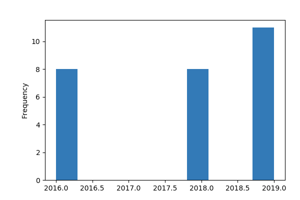

**Common Values**

| Value | Count | Frequency (%) |  |
| --- | --- | --- | --- |
| 2019 | 11 | 40.7% |  |
| 2018 | 8 | 29.6% |  |
| 2016 | 8 | 29.6% |  |

**Extreme Values**

Minimum 5 values

| Value | Count | Frequency (%) |  |
| --- | --- | --- | --- |
| 2016 | 8 | 29.6% |  |
| 2018 | 8 | 29.6% |  |
| 2019 | 11 | 40.7% |  |

Maximum 5 values

| Value | Count | Frequency (%) |  |
| --- | --- | --- | --- |
| 2016 | 8 | 29.6% |  |
| 2018 | 8 | 29.6% |  |
| 2019 | 11 | 40.7% |  |

spl_product_data_elements  
Categorical, Unique

| First 3 values |
| --- |
| 'CRESTOR Rosuvastatin calcium ROSUVASTATIN CALCIUM ROSUVASTATIN LACTOSE MONOHYDRATE CELLULOSE, MICROCRYSTALLINE HYPROMELLOSES TRIACETIN TITANIUM DIOXIDE FERRIC OXIDE YELLOW biconvex 5;crestor CRESTOR … |
| 'ATACAND Candesartan cilexetil CANDESARTAN CILEXETIL CANDESARTAN HYDROXYPROPYL CELLULOSE (1600000 WAMW) LACTOSE MONOHYDRATE STARCH, CORN CARBOXYMETHYLCELLULOSE CALCIUM MAGNESIUM STEARATE FERRIC OXIDE … |
| 'QTERN dapagliflozin and saxagliptin DAPAGLIFLOZIN DAPAGLIFLOZIN SAXAGLIPTIN HYDROCHLORIDE SAXAGLIPTIN ANHYDROUS ANHYDROUS LACTOSE CROSCARMELLOSE SODIUM FERROUS OXIDE MAGNESIUM STEARATE MICROCRYSTALLI… |

| Last 3 values |
| --- |
| 'NEXIUMI.V. Esomeprazole sodium ESOMEPRAZOLE SODIUM ESOMEPRAZOLE EDETATE DISODIUM SODIUM HYDROXIDE' |
| 'CAPRELSA Vandetanib VANDETANIB VANDETANIB CALCIUM PHOSPHATE, DIBASIC, DIHYDRATE CELLULOSE, MICROCRYSTALLINE CROSPOVIDONE (15 MPA.S AT 5%) POVIDONE, UNSPECIFIED MAGNESIUM STEARATE HYPROMELLOSES TITANI… |
| 'LUMOXITI moxetumomab pasudotox MOXETUMOMAB PASUDOTOX MOXETUMOMAB PASUDOTOX GLYCINE POLYSORBATE 80 SODIUM PHOSPHATE, MONOBASIC, MONOHYDRATE SUCROSE IV Solution Stabilizer IV Solution Stabilizer POLYSO… |

Toggle details

First 10 values

| Value | Count | Frequency (%) |  |
| --- | --- | --- | --- |
| 'ATACAND Candesartan cilexetil CANDESARTAN CILEXETIL CANDESARTAN HYDROXYPROPYL CELLULOSE (1600000 WAMW) LACTOSE MONOHYDRATE STARCH, CORN CARBOXYMETHYLCELLULOSE CALCIUM MAGNESIUM STEARATE FERRIC OXIDE … | 1 | 3.7% |  |
| 'ATACAND HCT Candesartan cilexetil and Hydrochlorothiazide CANDESARTAN CILEXETIL CANDESARTAN HYDROCHLOROTHIAZIDE HYDROCHLOROTHIAZIDE CARBOXYMETHYLCELLULOSE CALCIUM HYDROXYPROPYL CELLULOSE (1600000 WAM… | 1 | 3.7% |  |
| 'BEVESPI AEROSPHERE Glycopyrrolate and formoterol fumarate GLYCOPYRROLATE GLYCOPYRRONIUM FORMOTEROL FUMARATE FORMOTEROL 1,2-DISTEAROYL-SN-GLYCERO-3-PHOSPHOCHOLINE CALCIUM CHLORIDE NORFLURANE' | 1 | 3.7% |  |
| 'BYDUREON BCise exenatide EXENATIDE EXENATIDE POLY(DL-LACTIC-CO-GLYCOLIC ACID), (50:50; 63000 MW) SUCROSE CARBOXYMETHYLCELLULOSE SODIUM, UNSPECIFIED FORM SODIUM CHLORIDE POLYSORBATE 20 SODIUM PHOSPHAT… | 1 | 3.7% |  |
| 'BYDUREON exenatide EXENATIDE EXENATIDE POLY(DL-LACTIC-CO-GLYCOLIC ACID), (50:50; 63000 MW) SUCROSE CARBOXYMETHYLCELLULOSE SODIUM, UNSPECIFIED FORM SODIUM CHLORIDE POLYSORBATE 20 SODIUM PHOSPHATE, MON… | 1 | 3.7% |  |

Last 10 values

| Value | Count | Frequency (%) |  |
| --- | --- | --- | --- |
| 'TAGRISSO osimertinib OSIMERTINIB OSIMERTINIB MANNITOL MICROCRYSTALLINE CELLULOSE SODIUM STEARYL FUMARATE POLYVINYL ALCOHOL, UNSPECIFIED TITANIUM DIOXIDE POLYETHYLENE GLYCOL 3350 TALC FERRIC OXIDE YEL… | 1 | 3.7% |  |
| 'TOPROLXL Metoprolol succinate METOPROLOL SUCCINATE METOPROLOL METOPROLOL TARTRATE SILICON DIOXIDE SODIUM STEARYL FUMARATE TITANIUM DIOXIDE POLYETHYLENE GLYCOL 6000 PARAFFIN HYPROMELLOSES biconvex AB … | 1 | 3.7% |  |
| 'Tudorza Pressair aclidinium bromide ACLIDINIUM BROMIDE ACLIDINIUM lactose monohydrate' | 1 | 3.7% |  |
| 'ZOLADEX Goserelin acetate GOSERELIN ACETATE GOSERELIN GLYCOLIC ACID LACTIC ACID, DL-' | 1 | 3.7% |  |
| 'ZOLADEX Goserelin acetate GOSERELIN ACETATE GOSERELIN LACTIC ACID, DL- GLYCOLIC ACID' | 1 | 3.7% |  |

manufacturer_name  
Constant

*This variable is constant and should be ignored for analysis*

| Constant value | AstraZeneca Pharmaceuticals LP |
| --- | --- |

drug_names  
Categorical

| Distinct count | 26 |
| --- | --- |
| Unique (%) | 96.3% |
| Missing (%) | 0.0% |
| Missing (n) | 0 |

| ZOLADEX | 2 |
| --- | --- |
| TAGRISSO | 1 |
| PRILOSEC | 1 |
| Other values (23) | 23 |

Toggle details

| Value | Count | Frequency (%) |  |
| --- | --- | --- | --- |
| ZOLADEX | 2 | 7.4% |  |
| TAGRISSO | 1 | 3.7% |  |
| PRILOSEC | 1 | 3.7% |  |
| Lynparza | 1 | 3.7% |  |
| MOVANTIK | 1 | 3.7% |  |
| SymlinPen | 1 | 3.7% |  |
| TOPROL XL | 1 | 3.7% |  |
| SYMBICORT | 1 | 3.7% |  |
| BYDUREON BCise | 1 | 3.7% |  |
| CRESTOR | 1 | 3.7% |  |
| Other values (16) | 16 | 59.3% |  |

route  
Categorical

| Distinct count | 5 |
| --- | --- |
| Unique (%) | 18.5% |
| Missing (%) | 0.0% |
| Missing (n) | 0 |

| ORAL | 15 |
| --- | --- |
| SUBCUTANEOUS | 5 |
| RESPIRATORY (INHALATION) | 3 |
| Other values (2) | 4 |

Toggle details

| Value | Count | Frequency (%) |  |
| --- | --- | --- | --- |
| ORAL | 15 | 55.6% |  |
| SUBCUTANEOUS | 5 | 18.5% |  |
| RESPIRATORY (INHALATION) | 3 | 11.1% |  |
| INTRAVENOUS | 3 | 11.1% |  |
| nan | 1 | 3.7% |  |

number_of_ingredient  
Numeric

| Distinct count | 15 |
| --- | --- |
| Unique (%) | 55.6% |
| Missing (%) | 0.0% |
| Missing (n) | 0 |
| Infinite (%) | 0.0% |
| Infinite (n) | 0 |

| Mean | 10.296 |
| --- | --- |
| Minimum | 1 |
| Maximum | 27 |
| Zeros (%) | 0.0% |

Toggle details

**Statistics**

Quantile statistics

| Minimum | 1 |
| --- | --- |
| 5-th percentile | 2.3 |
| Q1 | 5.5 |
| Median | 9 |
| Q3 | 13.5 |
| 95-th percentile | 24.9 |
| Maximum | 27 |
| Range | 26 |
| Interquartile range | 8 |

Descriptive statistics

| Standard deviation | 6.8882 |
| --- | --- |
| Coef of variation | 0.669 |
| Kurtosis | 0.73008 |
| Mean | 10.296 |
| MAD | 5.4925 |
| Skewness | 0.94061 |
| Sum | 278 |
| Variance | 47.447 |
| Memory size | 344.0 B |

**Histogram**

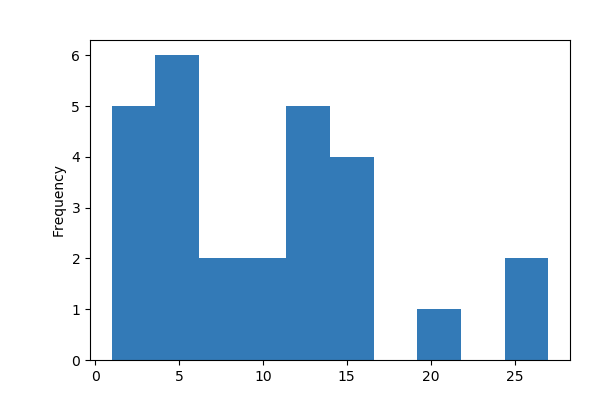

**Common Values**

| Value | Count | Frequency (%) |  |
| --- | --- | --- | --- |
| 13 | 4 | 14.8% |  |
| 6 | 4 | 14.8% |  |
| 15 | 3 | 11.1% |  |
| 3 | 3 | 11.1% |  |
| 27 | 2 | 7.4% |  |
| 8 | 2 | 7.4% |  |
| 20 | 1 | 3.7% |  |
| 14 | 1 | 3.7% |  |
| 12 | 1 | 3.7% |  |
| 11 | 1 | 3.7% |  |
| Other values (5) | 5 | 18.5% |  |

**Extreme Values**

Minimum 5 values

| Value | Count | Frequency (%) |  |
| --- | --- | --- | --- |
| 1 | 1 | 3.7% |  |
| 2 | 1 | 3.7% |  |
| 3 | 3 | 11.1% |  |
| 4 | 1 | 3.7% |  |
| 5 | 1 | 3.7% |  |

Maximum 5 values

| Value | Count | Frequency (%) |  |
| --- | --- | --- | --- |
| 13 | 4 | 14.8% |  |
| 14 | 1 | 3.7% |  |
| 15 | 3 | 11.1% |  |
| 20 | 1 | 3.7% |  |
| 27 | 2 | 7.4% |  |

liste_ingredient  
Unsupported

*This variable is an unsupported type, check if it needs cleaning or further analysis*

| Unsupported value |
| --- |

contains  
Boolean

| Distinct count | 2 |
| --- | --- |
| Unique (%) | 7.4% |
| Missing (%) | 0.0% |
| Missing (n) | 0 |

| Mean | 0.14815 |
| --- | --- |

| True | 4 |
| --- | --- |
| (Missing) | 23 |

Toggle details

| Value | Count | Frequency (%) |  |
| --- | --- | --- | --- |
| True | 4 | 14.8% |  |
| (Missing) | 23 | 85.2% |  |

Correlations

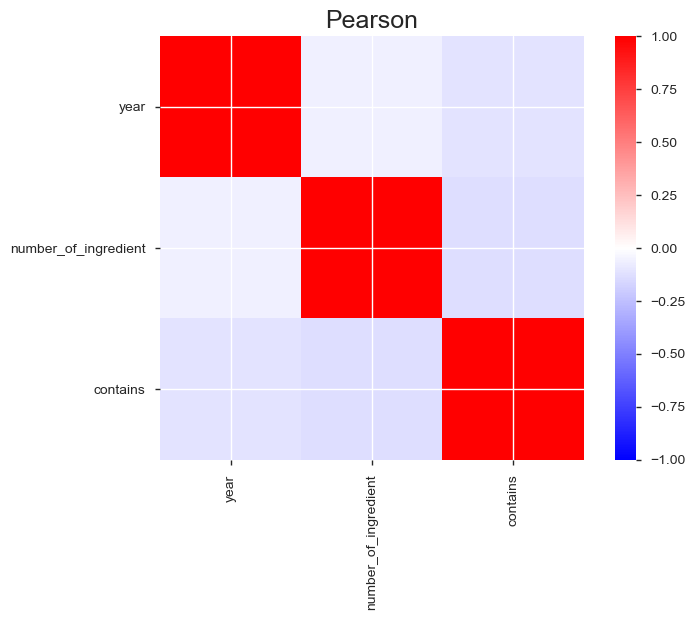

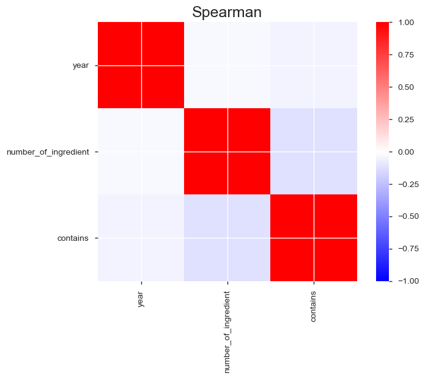

Sample

|  | year | spl_product_data_elements | manufacturer_name | drug_names | route | number_of_ingredient | liste_ingredient | contains |
| --- | --- | --- | --- | --- | --- | --- | --- | --- |
| 0 | 2019 | 'BYDUREON BCise exenatide EXENATIDE EXENATIDE POLY(DL-LACTIC-CO-GLYCOLIC ACID), (50:50; 63000 MW) SUCROSE CARBOXYMETHYLCELLULOSE SODIUM, UNSPECIFIED FORM SODIUM CHLORIDE POLYSORBATE 20 SODIUM PHOSPHAT… | AstraZeneca Pharmaceuticals LP | BYDUREON BCise | SUBCUTANEOUS | 13 | [exenatide, SODIUM CHLORIDE, POLYSORBATE 20 SODIUM PHOSPHATE, MONOBASIC, MONOHYDRATE SODIUM PHOSPHATE, DIBASIC, HEPTAHYDRATE WATER, SUCROSE CARBOXYMETHYLCELLULOSE SODIUM, CELLULOSE, POLYSORBATE, SODIU… | True |
| 1 | 2019 | 'QTERN dapagliflozin and saxagliptin DAPAGLIFLOZIN DAPAGLIFLOZIN SAXAGLIPTIN HYDROCHLORIDE SAXAGLIPTIN ANHYDROUS ANHYDROUS LACTOSE CROSCARMELLOSE SODIUM FERROUS OXIDE MAGNESIUM STEARATE MICROCRYSTALLI… | AstraZeneca Pharmaceuticals LP | QTERN | ORAL | 15 | [TITANIUM DIOXIDE, MICROCRYSTALLINE, MAGNESIUM STEARATE, POLYETHYLENE GLYCOL, CELLULOSE, TALC, POLYVINYL ALCOHOL, dapagliflozin, SAXAGLIPTIN HYDROCHLORIDE, ANHYDROUS LACTOSE, SILICON DIOXIDE, FERROUS … | False |
| 2 | 2016 | 'ATACAND HCT Candesartan cilexetil and Hydrochlorothiazide CANDESARTAN CILEXETIL CANDESARTAN HYDROCHLOROTHIAZIDE HYDROCHLOROTHIAZIDE CARBOXYMETHYLCELLULOSE CALCIUM HYDROXYPROPYL CELLULOSE (1600000 WAM… | AstraZeneca Pharmaceuticals LP | ATACAND HCT | ORAL | 11 | [MAGNESIUM STEARATE, POLYETHYLENE GLYCOL, CELLULOSE, FERRIC OXIDE YELLOW, FERRIC OXIDE RED, Candesartan cilexetil, Hydrochlorothiazide, STARCH, CORN, LACTOSE MONOHYDRATE, CALCIUM HYDROXYPROPYL, HYDROX… | False |
| 3 | 2016 | 'TOPROLXL Metoprolol succinate METOPROLOL SUCCINATE METOPROLOL METOPROLOL TARTRATE SILICON DIOXIDE SODIUM STEARYL FUMARATE TITANIUM DIOXIDE POLYETHYLENE GLYCOL 6000 PARAFFIN HYPROMELLOSES biconvex AB … | AstraZeneca Pharmaceuticals LP | TOPROL XL | ORAL | 9 | [HYPROMELLOSE, TITANIUM DIOXIDE, HYPROMELLOSES, POLYETHYLENE GLYCOL, SODIUM STEARYL FUMARATE, SILICON DIOXIDE, PARAFFIN, TARTRATE, METOPROLOL SUCCINATE] | False |
| 4 | 2016 | 'SymlinPen pramlintide acetate pramlintide acetate pramlintide metacresol mannitol acetic acid sodium acetate water SymlinPen pramlintide acetate pramlintide acetate pramlintide metacresol mannitol ac… | AstraZeneca Pharmaceuticals LP | SymlinPen | SUBCUTANEOUS | 6 | [metacresol, mannitol, acetic acid, sodium acetate, water, pramlintide acetate] | False |

```python
# Quickly explore
pandas_profiling.ProfileReport(data)
```

# Query Part A : Using SQL

### query :

- Using the data from the OpenFDA API (documentation at [Open fda gov](https://open.fda.gov/apis/drug/label/) to determine the average number of ingredients (spl_product_data_elements) contained in AstraZeneca medicines per year.

```python
part_a_df = data.groupby(['year','drug_names']).agg(['mean'])
part_a_df.drop(('contains','mean'), axis = 1, inplace = True)
df = part_a_df.rename_axis(['year',part_a_df.index.names[1]])
df
```

| year | drug_names | number_of_ingredient mean |
| --- | --- | --- |
| 2016 | ATACAND | 8.0 |
|  | ATACAND HCT | 11.0 |
|  | CAPRELSA | 13.0 |
|  | PRILOSEC | 27.0 |
|  | SymlinPen | 6.0 |
|  | TOPROL XL | 9.0 |
|  | ZOLADEX | 3.5 |
| 2018 | Byetta | 6.0 |
|  | CRESTOR | 15.0 |
|  | Daliresp | 3.0 |
|  | Esomeprazole magnesium | 20.0 |
|  | LOKELMA | 1.0 |
|  | Lynparza | 12.0 |
|  | NEXIUM | 27.0 |
|  | TAGRISSO | 15.0 |
| 2019 | BEVESPI AEROSPHERE | 6.0 |
|  | BYDUREON | 13.0 |
|  | BYDUREON BCise | 13.0 |
|  | IMFINZI | 5.0 |
|  | IRESSA | 14.0 |
|  | LUMOXITI | 8.0 |
|  | MOVANTIK | 13.0 |
|  | NEXIUM I.V. | 3.0 |
|  | QTERN | 15.0 |
|  | SYMBICORT | 6.0 |
|  | Tudorza Pressair | 2.0 |

```python
data.groupby(['year']).number_of_ingredient.agg(['mean'])
```

| year | mean |
| --- | --- |
| 2016 | 10.125000 |
| 2018 | 12.375000 |
| 2019 | 8.909091 |

```python
# filter the columns i need for the query A
plt.rcParams["figure.figsize"] = [9,5]
data_selection_a = data.iloc[:,[0,3,5]]
```

```python
# Query A SQL
q =''' select year, avg(number_of_ingredient) as avg_number_of_ingredient from data_selection_a group by year '''
requete_a = pd.DataFrame(pysqldf(q))
requete_a
```

|  | year | avg_number_of_ingredient |
| --- | --- | --- |
| 0 | 2016 | 10.125000 |
| 1 | 2018 | 12.375000 |
| 2 | 2019 | 8.909091 |

- methode 1

```python
import hvplot.pandas
requete_a.hvplot.bar(x = 'year', c = 'avg_number_of_ingredient', width=700, height=400,
                # We could write kind = 'bar' instead of .bar before parenthesis,
                title = 'The average number of ingredients contained in AstraZeneca medicines per year',
                xlabel = 'Year',
                ylabel = 'Average number of ingredients',
                grid = True,
                muted_color = 'black',
                rot = 90 ,# Rotate label
                cmap='prism', value_label='one')
```

[interactive chart not shown]

- methode 2

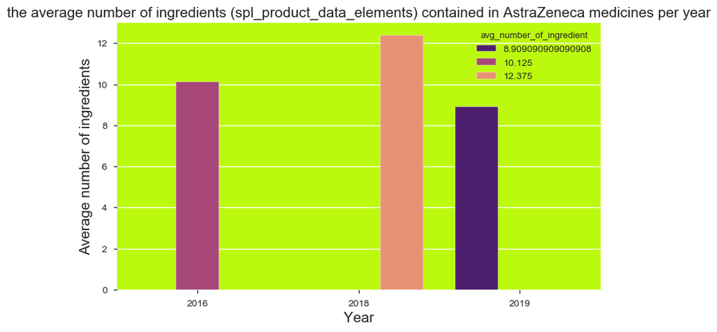

```python
plt.rcParams["figure.figsize"] = [9,5]

# Plot 1()
sns.barplot(x = 'year', y = 'avg_number_of_ingredient', hue = 'avg_number_of_ingredient',
            data = requete_a, palette = 'magma', edgecolor = 'w')
plt.title('the average number of ingredients (spl_product_data_elements) contained in AstraZeneca medicines per year', fontsize = 15)
plt.xlabel('Year', fontsize = 15)
plt.ylabel('Average number of ingredients', fontsize = 15)
ax = plt.gca()
ax.set_facecolor('xkcd:yellowgreen')
plt.show()
```

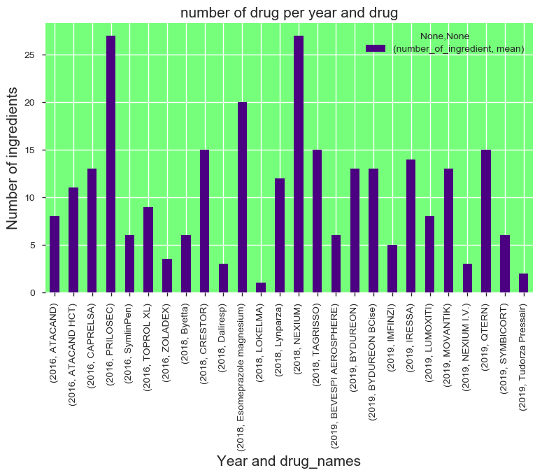

```python
plt.rcParams["figure.figsize"] = [9,5]
# Figure number of ingredient in a drug by year
df.plot(kind = 'bar', color='indigo')
plt.title('number of drug per year and drug', fontsize = 15)
plt.xlabel('Year and drug_names', fontsize = 15)
plt.ylabel('Number of ingredients', fontsize = 15)
ax = plt.gca()
ax.set_facecolor('xkcd:lightgreen')
plt.show()
```

# Query Part B : Using SQL

Query B : Repeat the same analysis, calculate the average number of ingredients per year and per delivery route for all manufacturers.

We have a 'nan' for the year 2019. i don't want to delete it cause we at least know that we have information missing in 2019. Maybe we could further fill it with KNN imputation maybe.

```python
# filter the columns i need for the query B
plt.rcParams["figure.figsize"] = [9,5]
data_selection_b = data.iloc[:,[0,4,5]]

# Query A SQL
q =''' select year, route, avg(number_of_ingredient) as avg_number_of_ingredient
       from data_selection_b group by route,year
       order by year desc'''

# print our query
requete_b = pd.DataFrame(pysqldf(q))
requete_b
```

|  | year | route | avg_number_of_ingredient |
| --- | --- | --- | --- |
| 0 | 2019 | INTRAVENOUS | 5.333333 |
| 1 | 2019 | ORAL | 14.000000 |
| 2 | 2019 | RESPIRATORY (INHALATION) | 4.666667 |
| 3 | 2019 | SUBCUTANEOUS | 13.000000 |
| 4 | 2019 | nan | 13.000000 |
| 5 | 2018 | ORAL | 13.285714 |
| 6 | 2018 | SUBCUTANEOUS | 6.000000 |
| 7 | 2016 | ORAL | 13.600000 |
| 8 | 2016 | SUBCUTANEOUS | 4.333333 |

```python
# Group by Pandas
requete_b.groupby(['year','route']).agg(['mean'])
```

| year | route | avg_number_of_ingredient mean |
| --- | --- | --- |
| 2016 | ORAL | 13.600000 |
|  | SUBCUTANEOUS | 4.333333 |
| 2018 | ORAL | 13.285714 |
|  | SUBCUTANEOUS | 6.000000 |
| 2019 | INTRAVENOUS | 5.333333 |
|  | ORAL | 14.000000 |
|  | RESPIRATORY (INHALATION) | 4.666667 |
|  | SUBCUTANEOUS | 13.000000 |
|  | nan | 13.000000 |

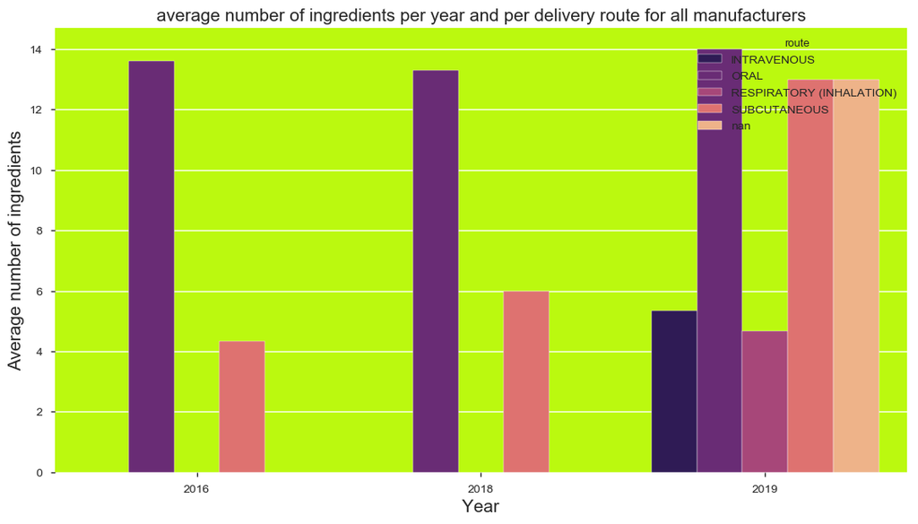

```python
plt.rcParams["figure.figsize"] = [13,15]

# Plot1()
plt.subplot(211)
# "Average Number of ingredients vs Time"
sns.barplot(x = 'year', y = 'avg_number_of_ingredient', hue = 'route',
            data = requete_b, palette = 'magma', edgecolor = 'w')
plt.title('average number of ingredients per year and per delivery route for all manufacturers', fontsize = 15)
plt.xlabel('Year', fontsize = 15)
plt.ylabel('Average number of ingredients', fontsize = 15)
ax = plt.gca()
ax.set_facecolor('xkcd:yellowgreen')
plt.show()
```

```python
requete_b.set_index('year').hvplot(c ='avg_number_of_ingredient', legend = True, width=1000, height=400,
                kind ='bar',
                title = 'the average number of ingredients contained in AstraZeneca medicines per year',
                xlabel = 'Year',
                ylabel = 'Average number of ingredients',
                grid = True,
                stacked = False,

                cmap='Category10', value_label='one')
```

[interactive chart not shown]